# Rappresentazioni grafiche di tre o più dimensioni

## Dati Measures

Importare i dati `measures`.

```r
measure <- read.csv("~/Dropbox/Public/AE/Data/measure.csv")
```

1. Costruire il diagramma tridimensionale per le variabili `chest`, `waist` e `hips`, utilizzando il comando `cloud()` che è disponibile nel pacchetto `lattice`:

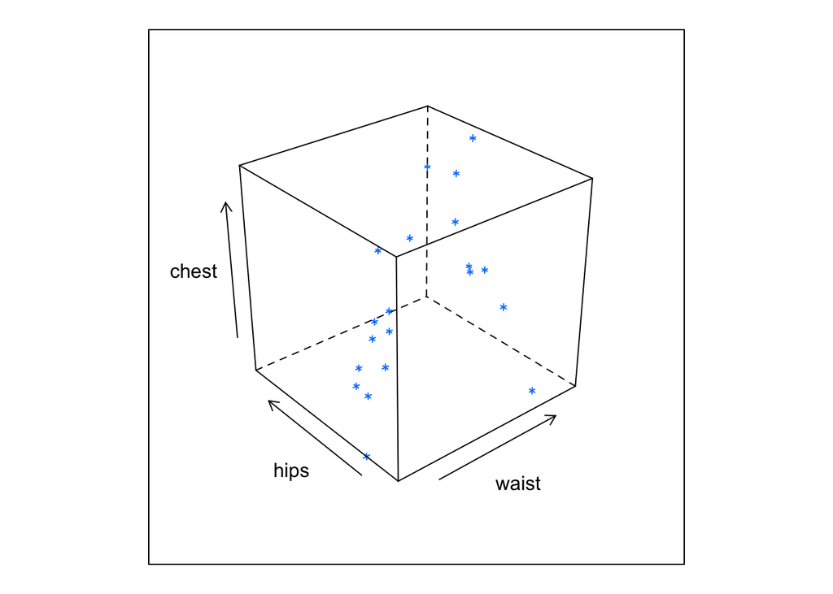

```r
require(lattice)
cloud(chest ~ waist + hips, data=measure)
```

2. Costruire il diagramma tridimensionale colorando le unità statistiche con colori diversi a seconda del sesso.

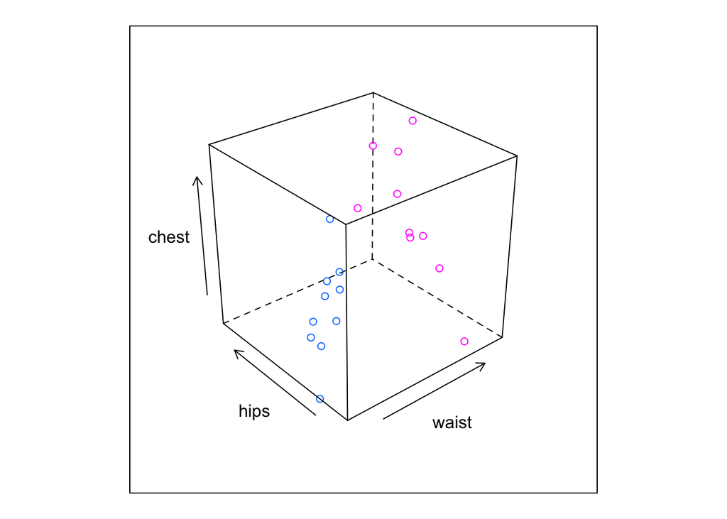

```r
cloud(chest ~ waist + hips, group=gender, data=measure)
```

3. Costruire la matrice dei diagrammi di dispersione colorando le unità statistiche con colori diversi a seconda del sesso, e commentare.

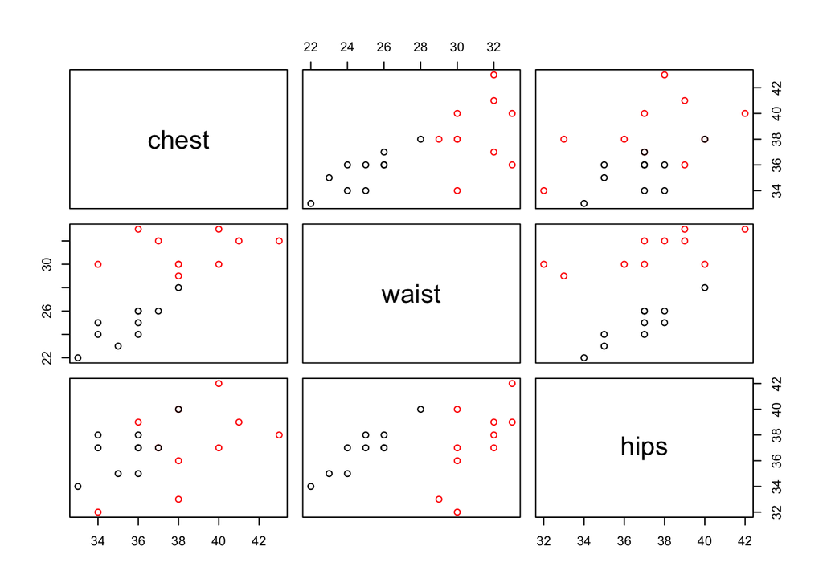

```r
column.gender <- which(names(measure)=="gender")
plot(measure[,-column.gender], col=(measure$gender=="male")+1)
```

4. Costruire le facce di Chernoff corrispondenti ai 20 individui escludendo la variabile `gender` utilizzando il comando `faces()` presente nel pacchetto `TeachingDemos`:

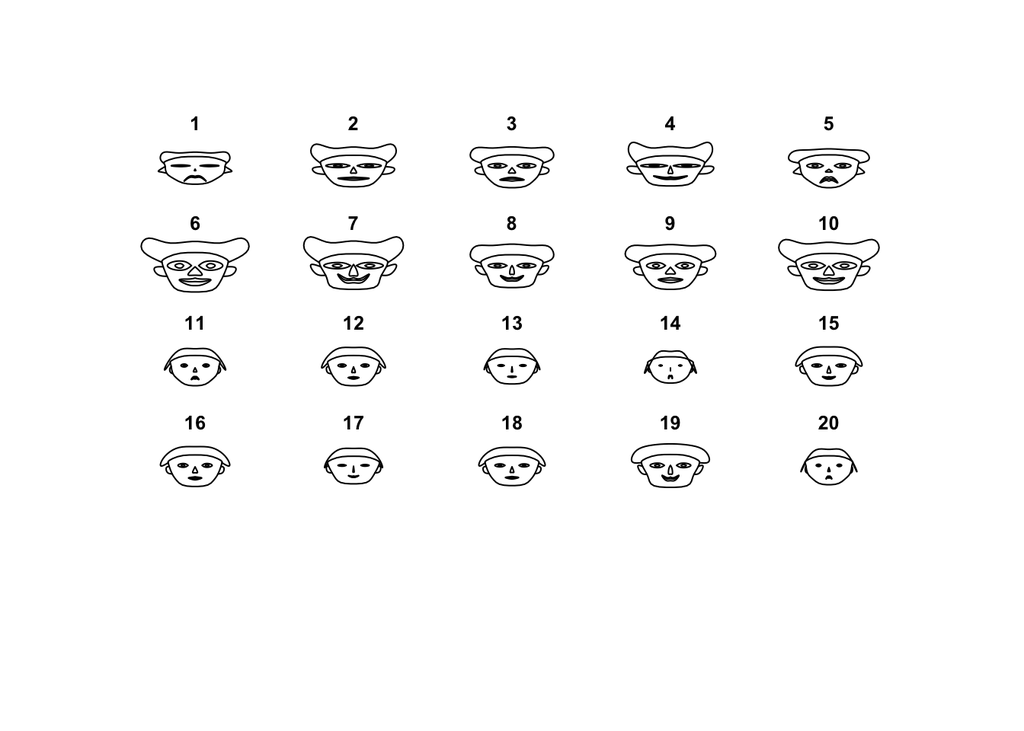

```r
library("TeachingDemos")
faces(measure[,-column.gender], scale=TRUE)
```

5. Rappresentare gli individui con le stelle utilizzando il comando `stars()`, aggiungendo la legenda con l’argomento `key.loc = c(12,10)`.

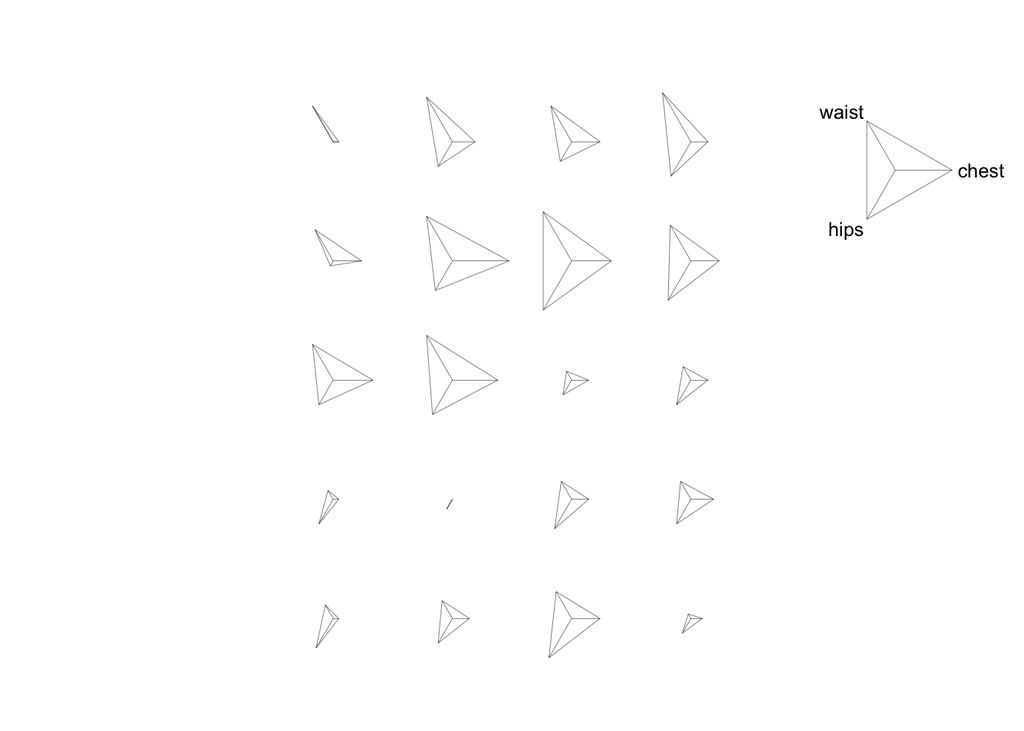

```r
stars(measure[,-column.gender], scale=TRUE, key.loc = c(12, 10))
```

## Dati Quakes

Il data.frame `quakes` è presente nel pacchetto `dataset`. Si tratta di 1000 osservazioni misurate su 5 variabili:

- lat Latitude of event
- long Longitude
- depth Depth (km)
- mag Richter Magnitude
- stations Number of stations reporting

Il diagramma di dispersione per latitudine e longitudine dei terremoti, utilizzando il simbolo `.` per indicare le osservazioni, è dato da:

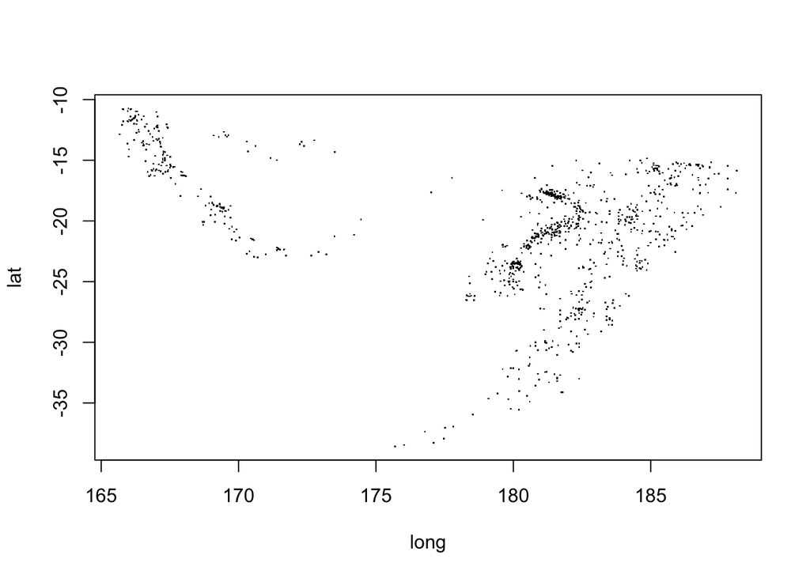

```r
data("quakes")
plot(lat ~ long, quakes, pch=".")
```

1. Costruire il diagramma di dispersione di latitudine e longitudine condizionato ai 4 intervallo di profondità disgiunti (ottenendoli con il comando `co.intervals()`) e commentare.

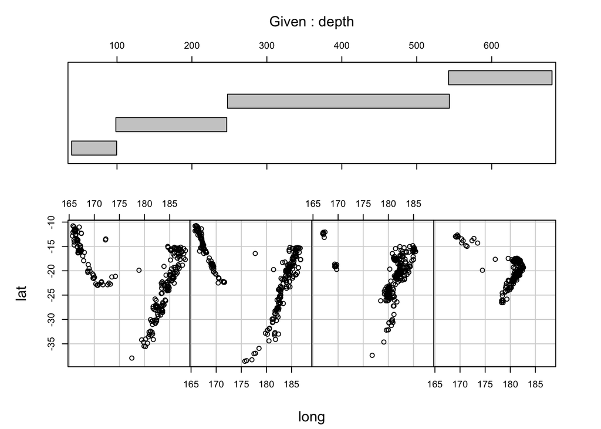

```r
intervalli <- co.intervals(quakes$depth, number=4, overlap=0)
coplot(lat ~ long | depth, data = quakes, given.v = intervalli, rows = 1)
```